# Chris Ruff – Functional Anatomy & Evolution: European-Data-Set-7-22.xlsx

Transfer the data into R and SQLite

Christoph Rinne

ver. 0.0 2026-06

## 1 Introduction

The original Excel file ‘European-Data-Set-7-22.xlsx’ with supplementary information [PDF](https://fae.johnshopkins.edu/wp-content/uploads/2022/08/Notes-on-European-Data-Set-7-22.pdf) derives from and can be downloaded from: http://www.hopkinsmedicine.org/fae/CBR.html.

> Please download the file yourself; the website blocks simple automated downloads via download.file() or GET().

> This document aims at a ready-to-use transformation of the original variable names in R and SQLite, compiling a minimal set of information for the variables and a structural reorganisation of the data in the SQLite database for further data processing and investigation.

The data in the Excel file were collected as part of a project funded primarily by the US National Science Foundation and carried out between 2007 and 2015. The primary researchers involved in the project were Christopher Ruff (Johns Hopkins University, Baltimore, cbruff@jhmi.edu), Brigitte Holt (University of Massachusetts, Amherst, holtmb@hotmail.com), Markku Niskanen (University of Oulu, Finland, markku.niskanen@oulu.fi), Vladimir Sládek (Charles University, Prague, sladekv@yahoo.fr), and Margit Berner (Natural History Museum, Vienna, margit.berner@NHM-WIEN.AC.AT).

All code is integrated into this document and can be viewed with [Show].

```r
# Set document default values.
# Load & install pacman to load the needed R packages.
Sys.setlocale("LC_ALL", "English_United Kingdom.65001")
```

```
## [1] "LC_COLLATE=English_United Kingdom.utf8;LC_CTYPE=English_United Kingdom.utf8;LC_MONETARY=English_United Kingdom.utf8;LC_NUMERIC=C;LC_TIME=English_United Kingdom.utf8"
```

```r
knitr::opts_chunk$set(echo = TRUE, fig.align="center", include = TRUE)
require(pacman) || install.packages("pacman")
```

```
## [1] TRUE
```

```r
pacman::p_load(DBI, ggplot2, readxl, tidyr)
```

## 2 Data processing

Read the original Excel file into the R environment.

```r
d <- readxl::read_excel("./European-Data-Set-7-22.xlsx")
```

The variable names have some inconvenient symbols for easy use in R or SQL statements. In addition, there are some further inconsistencies, e.g. abbreviations and punctuation. We therefore convert all variable names to lowercase and replace all non-letters or digits with a single “_”, preferable for use in R and SQLite. In addition we provide a table with the original and changed variable names, adding a column with condensed information derived from the provided [PDF](https://fae.johnshopkins.edu/wp-content/uploads/2022/08/Notes-on-European-Data-Set-7-22.pdf) from the data source (see above). Unfortunately not all are explained adequately, e.g. for ‘LHIX’ only ‘IX’ is explained and we suggest ‘LH’ to be read as ‘left humerus’ although Femur and Tibia have variable ‘FSIDE’ for laterality.

Due to personal convenience and competence the data processing is split into a part for variable naming in R and structural reorganisation in SQLite. Please take into account ‘*type affinity*’ in the SQLite database.

### 2.1 R: variable names & information

```r
# get original variable names
varnames_orig <- colnames(d)
# change to lower and non letters or digits to a single _ using anonym lambda
varnames_clean <- tolower(varnames_orig) |>
  (\(v) gsub("[^a-z,0-9]", "_", v))() |>
  (\(v) gsub("_$","",v))() |>
  (\(v) gsub("__","_",v))()
```

Provide variable information.

```r
varnames_info <- c(
  "Investigator",
  "Period, temporal",
  "Subperiod, e.g. prehistoric periods",
  "Period number",
  "Original dates, e.g. AD/BC, BP uncalibrated/calibrated",
  "Mean age in years BP of `Date range`. BP = 2000AD for recent period",
  "Region",
  "Subregion",
  "Region number",
  "Information on archaeological associations, ethnicity, or other lifestyle attributes, as appropriate",
  "Site name",
  "Specimen number in the local context",
  "Collection providor",
  "Latitude",
  "Longitude",
  "Average slopes within a 10 km radius of each site",
  "Maximum slopes within a 10 km radius of each site",
  "codes of 1: flat, 2: hilly, 3: mountainous",
  "codes of 1: rural and 2: urban",
  "codes of 1: male, 2: female",
  "Specific ages for known-age for Very recent or Early modern individuals,  ranges for others",
  "means of ranges or 38 (mean of pooled sample) for unknown.",
  "Bi-iliac breadth, does not include any soft tissue correction",
  "M-L breadth described by Tague (1989), ), measured between the most anterior points of the auricular surfaces",
  "ML2 is maximum M-L breadth of the entire sacrum",
  "",
  "",
  "Sum of vertebral body heights (maximum anterior to the pedicles) of L5 through C2",
  "Anterior height of S1 sacral segment",
  "Basion-bregma height",
  "Talar+calcaneal height",
  "Sum of TAL-CAL HT., FBICLN, TFULLN, S1HT, PRESACRAL HT. and BAS-BREG HT",
  "Anatomical stature calculated with all dimensions except basion-bregma height",
  "Calculate anatomical (living) stature",
  "Calculated from full skeletal height, where available (n = 537), for others calculated from long bone lengths using formulae derived from this sample (Ruff et al., 2012)",
  "kg, calculated from stature and bi-iliac breadth (when both dimensions were available) or femoral head S-I breadth",
  "Femur, code of 1: right, 2: left",
  "Femur maximum length (Fem1)",
  "Femur bicondylar length (Fem2)",
  "Femur biomechanical length, used to locate cross sections",
  "femoral head S-I breadth",
  "femoral distal articular M-L breadth",
  "Femur shaft breadths at the given locations (50% or 35% of biomechanical length from the distal endpoint of that length)",
  "Femur shaft breadths at the given locations (50% or 35% of biomechanical length from the distal endpoint of that length)",
  "Tibia, code of 1: right, 2: left",
  "Tibia maximum length (including tibial spines)(Tib1a)",
  "Tibia  length used in anatomical stature calculation",
  "Tibia  biomechanical length, used to locate cross sections (L missing?)",
  "tibial plateau M-L breadth",
  "Tibia shaft breadths at the given locations (50% or 35% of biomechanical length from the distal endpoint of that length)",
  "Tibia shaft breadths at the given locations (50% or 35% of biomechanical length from the distal endpoint of that length)",
  "Humerus, right, maximum length (Hum1)",
  "Humerus, right, bicondylar length",
  "Humerus, right,  head S-I breadth",
  "Humerus, right, distal articular M-L breadth",
  "Humerus, right, shaft breadths at the given locations (50% or 35% of biomechanical length from the distal endpoint of that length)",
  "Humerus, right, shaft breadths at the given locations (50% or 35% of biomechanical length from the distal endpoint of that length)",
  "Humerus, right, shaft breadths at the given locations (50% or 35% of biomechanical length from the distal endpoint of that length)",
  "Humerus, right, shaft breadths at the given locations (50% or 35% of biomechanical length from the distal endpoint of that length)",
  "Humerus, left, maximum length (Hum1)",
  "Humerus, left, bicondylar length",
  "Humerus, left,  head S-I breadth",
  "Humerus, left, distal articular M-L breadth",
  "Humerus, left, shaft breadths at the given locations (50% or 35% of biomechanical length from the distal endpoint of that length)",
  "Humerus, left, shaft breadths at the given locations (50% or 35% of biomechanical length from the distal endpoint of that length)",
  "Humerus, left, shaft breadths at the given locations (50% or 35% of biomechanical length from the distal endpoint of that length)",
  "Humerus, left, shaft breadths at the given locations (50% or 35% of biomechanical length from the distal endpoint of that length)",
  "Radius, right, maximum length (R1b)",
  "Radius, right, bicondylar length",
  "Radius, left, maximum length",
  "Radius, left, bicondylar length",
  "Femur, second moments of area about the x and y axes (A-P and M-L bending rigidities, respectively)",
  "Femur, second moments of area about the x and y axes (A-P and M-L bending rigidities, respectively)",
  "Femur, section moduli about the x and y axes (A-P and M-L bending strengths, respectively)",
  "Femur, section moduli about the x and y axes (A-P and M-L bending strengths, respectively)",
  "Femur, total subperiosteal areas",
  "Femur, total cortical areas",
  "Femur, maximum and minimum second moments of area (bending rigidities)",
  "Femur, maximum and minimum second moments of area (bending rigidities)",
  "Femur, polar second moment of area (torsional and (twice) average bending rigidity)",
  "Femur, polar section modulus (torsional and (twice) average bending strength)",
  "Tibia, second moments of area about the x and y axes (A-P and M-L bending rigidities, respectively)",
  "Tibia, second moments of area about the x and y axes (A-P and M-L bending rigidities, respectively)",
  "Tibia, section moduli about the x and y axes (A-P and M-L bending strengths, respectively)",
  "Tibia, section moduli about the x and y axes (A-P and M-L bending strengths, respectively)",
  "Tibia, total subperiosteal areas",
  "Tibia, total cortical areas",
  "Tibia, maximum and minimum second moments of area (bending rigidities)",
  "Tibia, maximum and minimum second moments of area (bending rigidities)",
  "Tibia, polar second moment of area (torsional and (twice) average bending rigidity)",
  "Tibia, polar section modulus (torsional and (twice) average bending strength)",
  "Humerus, left, second moments of area about the x and y axes (A-P and M-L bending rigidities, respectively)",
  "Humerus, left, second moments of area about the x and y axes (A-P and M-L bending rigidities, respectively)",
  "Humerus, left, section moduli about the x and y axes (A-P and M-L bending strengths, respectively)",
  "Humerus, left, section moduli about the x and y axes (A-P and M-L bending strengths, respectively)",
  "Humerus, left, total subperiosteal areas",
  "Humerus, left, total cortical areas",
  "Humerus, left, maximum and minimum second moments of area (bending rigidities)",
  "Humerus, left, maximum and minimum second moments of area (bending rigidities)",
  "Humerus, left, polar second moment of area (torsional and (twice) average bending rigidity)",
  "Humerus, left, polar section modulus (torsional and (twice) average bending strength)",
  "Humerus, right, second moments of area about the x and y axes (A-P and M-L bending rigidities, respectively)",
  "Humerus, right, second moments of area about the x and y axes (A-P and M-L bending rigidities, respectively)",
  "Humerus, right, section moduli about the x and y axes (A-P and M-L bending strengths, respectively)",
  "Humerus, right, section moduli about the x and y axes (A-P and M-L bending strengths, respectively)",
  "Humerus, right, total subperiosteal areas",
  "Humerus, right, total cortical areas",
  "Humerus, right, maximum and minimum second moments of area (bending rigidities)",
  "Humerus, right, maximum and minimum second moments of area (bending rigidities)",
  "Humerus, right, polar second moment of area (torsional and (twice) average bending rigidity)",
  "Humerus, right, polar section modulus (torsional and (twice) average bending strength)"
)
```

Rename the variables, combine the previous information into the dataframe var_info and write this into an external CSV.

```r
colnames(d) <- varnames_clean
cbind(varnames_orig, varnames_clean, varnames_info) |>
  as.data.frame() -> var_info
write.csv(var_info, "var_info.csv")
```

For convenience we convert some variables to factors according to the provided codes.

```r
d$terr_code <- factor(d$terr_code,
                         levels = c(1, 2, 3),
                         labels = c("flat", "hilly", "mountainous"))
d$rural_urban <- factor(d$rural_urban,
                           levels = c(1, 2),
                           labels = c("rural", "urban"))
d$sex <- factor(d$sex,
                levels = c(1, 2),
                labels = c("male", "female"))
d$fside <- factor(d$fside,
                  levels = c(1, 2),
                  labels = c("right", "left"))
d$tside <- factor(d$tside,
                  levels = c(1, 2),
                  labels = c("right", "left"))
```

Example of the changes:

```r
head(var_info, n = 6) |>
knitr::kable()
```

| varnames_orig | varnames_clean | varnames_info |
| --- | --- | --- |
| INVEST | invest | Investigator |
| PERIOD | period | Period, temporal |
| SUBPERIOD | subperiod | Subperiod, e.g. prehistoric periods |
| PERIODNO | periodno | Period number |
| DATE RANGE | date_range | Original dates, e.g. AD/BC, BP uncalibrated/calibrated |
| YEARS BP | years_bp | Mean age in years BP of `Date range`. BP = 2000AD for recent period |

### 2.2 Data inconsistency

Looking at the variables for the bone measurements there are two different strategies in **recording laterality**. While there is only one set of measures for Femur and Tibia with a decision on left or right side, we expect the prefix HR, HL, RH, LH, RR, RL to represent left and right Humerus or Radius. If this is true, in many cases two measurements for each measure are present. In addition, the variables should be renamed in favour of a consistent prefix.

```r
varnames_orig[grep("^[HLR][HLR]",varnames_orig)] |>
  paste(collapse = ", ") |>
  cat()
```

```
## HRMAXLN, HRBIOLN, HRHDSI, HRDML, HR35AP, HR35ML, HR50AP, HR50ML, HLMAXLN, HLBIOLN, HLHDSI, HLDML, HL35AP, HL35ML, HL50AP, HL50ML, RRMAXLN, RRBIOLN, RLMAXLN, RLBIOLN, LHIX, LHIY, LHZX, LHZY, LHTA, LHCA, LHIMAX, LHIMIN, LHJ, LHZP, RHIX, RHIY, RHZX, RHZY, RHTA, RHCA, RHIMAX, RHIMIN, RHJ, RHZP
```

```r
# gsub-expression changes the order of the two leading letters
# change v to the corresponding vector, e.g. varnames_orig
varnames_orig[grep("^[HLR][HLR]",varnames_orig)] |>
  (\(v) gsub("^([LR])([HR])(.+)","\\2\\1\\3", v))() |>
  paste(collapse = ", ") |>
  cat()
```

```
## HRMAXLN, HRBIOLN, HRHDSI, HRDML, HR35AP, HR35ML, HR50AP, HR50ML, HLMAXLN, HLBIOLN, HLHDSI, HLDML, HL35AP, HL35ML, HL50AP, HL50ML, RRMAXLN, RRBIOLN, RLMAXLN, RLBIOLN, HLIX, HLIY, HLZX, HLZY, HLTA, HLCA, HLIMAX, HLIMIN, HLJ, HLZP, HRIX, HRIY, HRZX, HRZY, HRTA, HRCA, HRIMAX, HRIMIN, HRJ, HRZP
```

During our work we noticed some inconsistencies in the **subregion data**.

```r
d$subregion[d$subregion == "C.Sweden"] <- "Central Sweden"
d$subregion[d$subregion == "C. Sweden"] <- "Central Sweden"
d$subregion[d$subregion == "Northeast Italy"] <- "NE Italy"
d$subregion[d$subregion == "Northern France"] <- "N France"
d$subregion[d$subregion == "Northwest France"] <- "NW France"
d$subregion[d$subregion == "Northern Italy"] <- "N Italy"
d$subregion[d$subregion == "Northwest Italy"] <- "NW Italy"
d$subregion[d$subregion == "N. England"] <- "N England"
d$subregion[d$subregion == "S. Sweden"] <- "S Sweden"
d$subregion[d$subregion == "S.Finland"] <- "S Finland"
d$subregion[d$subregion == "S. England"] <- "S England"
d$subregion[d$subregion == "Southeast France"] <- "SE France"
d$subregion[d$subregion == "Southern France"] <- "S France"
d$subregion[d$subregion == "Southern Italy"] <- "S Italy"
d$subregion[d$subregion == "Southwest France"] <- "SW France"
table(d$subregion) |>
  knitr::kable(col.names = c("subregion", "count"),
               caption = "subregions")
```

subregions

| subregion | count |
| --- | --- |
| Bosnia-Herzegovina | 54 |
| Central-coastal Italy | 22 |
| Central France | 36 |
| Central Italy | 15 |
| Central Sweden | 201 |
| Cnt/NE Spain | 22 |
| Czech Republic | 9 |
| Denmark | 97 |
| E Austria | 303 |
| Finland | 70 |
| France | 1 |
| Germany | 5 |
| Italy/Alps | 1 |
| N England | 181 |
| N France | 1 |
| N Italy | 2 |
| N Spain | 43 |
| NE Czech Republic | 28 |
| NE Italy | 44 |
| NE Spain | 23 |
| NW Czech Republic | 162 |
| NW France | 17 |
| NW Italy | 9 |
| Portugal | 85 |
| Russia | 1 |
| S England | 135 |
| S Finland | 53 |
| S France | 2 |
| S Italy | 13 |
| S Romania | 17 |
| S Sweden | 101 |
| Sardinia | 10 |
| Scandinavia | 7 |
| SE Czech Republic | 78 |
| SE France | 37 |
| SE Germany | 119 |
| SE Italy | 37 |
| SE Spain | 34 |
| SW France | 45 |
| SW Italy | 49 |
| Swiss Alps | 3 |
| W Austria | 4 |
| Wales | 1 |

### 2.3 SQLite: data structure reorganisation

Create and set a connection to a SQLite database: EuropeanDataSet_22_07.sqlite. Write boath dataframes into the the database.

```r
db01 <- DBI::dbConnect(RSQLite::SQLite(),
                       dbname = "./EuropeanDataSet_22_07.sqlite")
DBI::dbWriteTable(db01, "orig_table", d, overwrite = TRUE)
DBI::dbWriteTable(db01, "var_info", var_info, overwrite = TRUE)
```

#### 2.3.1 Create a table sites

Write the site-specific information into its own table. Several sites differ by period or investigator. This redundancy is preserved in favour of a simple structure with minimal changes. In addition, we concatenate the rowids as column orig_ids of the original dataset for further data processing.

```r
site_vars <- var_info$varnames_clean[c(11,1:10,13:19)] |>
  paste(collapse = ", ")
sql <- paste0("create table sites as select ",
              site_vars,
              ", group_concat(rowid) as orig_ids",
              " from orig_table group by ",
              site_vars,
              ";")
DBI::dbExecute(db01, "drop table if exists sites;")
```

```
## [1] 0
```

```r
DBI::dbExecute(db01, sql)
```

```
## [1] 0
```

```r
sql <- NULL
site_vars <- NULL
```

The new table sites provides 320 records in total but only 272 distinct site names. It seems unlikely that this always happened by intention, e.g. the two Braunsdorf sites where only the coordinates differ. The multiple site names are:

```r
sql <- "select group_concat(site ||': '|| n, ', ') as 'multiple site names'
        from (select site, count(*) as n from sites
        group by 1 having n > 1);"
DBI::dbGetQuery(db01, sql)[1,1] |>
  cat()
```

```
## Arene Candide: 4, Braunsdorf: 2, Bystrocice: 2, Cockey Down: 2, Cro-Magnon: 3, Culoz: 2, Dolní Vestonice: 3, Erfurt-Nordhauser St.: 2, Franzhausen: 2, Franzhausen I: 2, Grotte des Enfants: 3, Hazleton North: 2, Helsinki: 10, Hoedic: 2, Los Canes: 3, Luis Lopez Collection: 2, Moita de Sebastiao: 2…
```

As the site names are not unique at the current level, we have to add an additional site_id. The current dataframe is written into the SQLite database. Unfortunately the “site_id” is the last column. To change the order is easier in R.

```r
DBI::dbExecute(db01, "alter table sites add column site_id integer;")
```

```
## [1] 0
```

```r
DBI::dbExecute(db01, "update sites set site_id = rowid;")
```

```
## [1] 320
```

```r
sites <- dbReadTable(db01, "sites")
sites <- cbind(site_id = sites$site_id,
               sites[,1:19]) |>
  as.data.frame()
DBI::dbWriteTable(db01, "sites", sites, overwrite = TRUE)
```

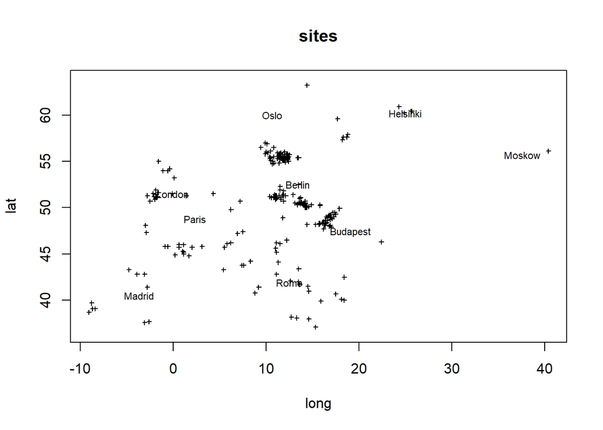

```r
psites <- dbGetQuery(db01, "select site, latitude, longitude
                    from sites group by 1, 2, 3;")
capitals <- rbind(
  c(lat = 40.5, long = -3.7, name = "Madrid"),
  c(48.8, 2.3, "Paris"),
  c(51.5, -0.1, "London"),
  c(52.5, 13.4, "Berlin"),
  c(47.5, 19.1, "Budapest"),
  c(41.9, 12.5, "Rome"),
  c(60, 10.7, "Oslo"),
  c(60.2, 25, "Helsinki"),
  c(55.7, 37.6, "Moskow")
) |>
  as.data.frame()
capitals$lat <- as.numeric(capitals$lat)
capitals$long <- as.numeric(capitals$long)
plot(psites$longitude, psites$latitude, pch = 3, cex = 0.5,
     asp = 1, xlab = "long", ylab = "lat", main = "sites")
text(capitals$long, capitals$lat, capitals$name, cex = 0.7, adj = c(0.5,0.5))
```

```r
psites <- NULL
```

#### 2.3.2 Create a table individuals

We select all variables not included in the table sites, add a column for the site_id and create a table in the SQL database selecting these data from the original table. The corresponding site_id for each record in this table is updated within a for-loop with a sql update statement based on the concatenated rowids in the corresponding orig_ids field.

```r
ind_vars <- varnames_clean[c(12,20:111)] |>
  paste0(collapse = ", ")
DBI::dbExecute(db01, "drop table if exists individuals;")
```

```
## [1] 0
```

```r
sql <- paste0("create table individuals as ",
              "select 0 as site_id, ",
              ind_vars,
              " from orig_table;")
DBI::dbExecute(db01, sql)
```

```
## [1] 0
```

```r
for (i in 1:length(sites$site_id)){
  orig_ids <- sites$orig_ids[sites$site_id == i]
  sql <- paste0("update individuals as i ",
                "set site_id = ", i ,
                " where i.rowid in (",
                orig_ids, ");")
  dbExecute(db01, sql)
}
ind_vars <- NULL
sql <- NULL
orig_ids <- NULL
```

Unfortunately there is one duplicate combination of site and specimen_no.

```sql
select s.site, i.specimen_no, i.sex, i.age_range, i.age_mean, i.stature
from individuals as i left join sites as s on s.site_id = i.site_id
where i.site_id||"_"||i.specimen_no in
(select site_id||"_"||specimen_no as id
from individuals
group by 1
having count(*) > 1)
```

2 records

| site | specimen_no | sex | age_range | age_mean | stature |
| --- | --- | --- | --- | --- | --- |
| Vrsany | 10 | male | 25-55 | 40 | NA |
| Vrsany | 10 | male | 50+ | 55 | 169.15 |

To get a clean identification of each record set we create ind_id using the rowid in the current table.

```r
DBI::dbExecute(db01, "alter table individuals add column ind_id integer;")
```

```
## [1] 0
```

```r
DBI::dbExecute(db01, "update individuals set ind_id = rowid;")
```

```
## [1] 2177
```

```r
individuals <- dbReadTable(db01, "individuals")
# move the ind_id to the first position
individuals <- cbind(ind_id = individuals[,95],
                     individuals[,1:94]) |>
  as.data.frame()
# convert fside and tside back to factor (left/right of Femur/Tibia)
individuals$fside <- factor(individuals$fside,
                  levels = c("right", "left"),
                  labels = c("right", "left"))
individuals$tside <- factor(individuals$tside,
                  levels = c("right", "left"),
                  labels = c("right", "left"))
```

#### 2.3.3 Reorganizing individuals

The table for the individuals provides 95 variables, many of them without content (NULL): 65072 of 2177, 111. Visibility and performance can be improved if we transform this table to a long list of variables and corresponding values. The SQLite type affinity supports this strategy whereas in R the type of a variable has to be numeric or string. Fortunately all variables after age_range are numeric, apart from the factor variables fside and tside, the laterality of Femur and Tibia.

```r
individuals$fside <- as.integer(individuals$fside)
individuals$tside <- as.integer(individuals$tside)
ind_measures <- tidyr::pivot_longer(individuals,
                            cols = 6:95,
                            names_to = "variable",
                            values_to = "value",
                            values_drop_na = TRUE)
DBI::dbWriteTable(db01, "ind_measures", ind_measures, overwrite = TRUE)
ind_measures[1:10,] |>
  knitr::kable()
```

| ind_id | site_id | specimen_no | sex | age_range | variable | value |
| --- | --- | --- | --- | --- | --- | --- |
| 1 | 117 | A284 | male | 49 | age_mean | 49.00 |
| 1 | 117 | A284 | male | 49 | tal_cal_ht | 72.90 |
| 1 | 117 | A284 | male | 49 | stature | 170.65 |
| 1 | 117 | A284 | male | 49 | body_mass | 71.90 |
| 1 | 117 | A284 | male | 49 | fside | 1.00 |
| 1 | 117 | A284 | male | 49 | fmaxln | 462.00 |
| 1 | 117 | A284 | male | 49 | fbicln | 459.00 |
| 1 | 117 | A284 | male | 49 | fbioln | 437.00 |
| 1 | 117 | A284 | male | 49 | fhdsi | 49.50 |
| 1 | 117 | A284 | male | 49 | fdml | 80.80 |

Unfortunately, the size of the dataset increases significantly due to the many duplicate values in the first five columns. We should split the data into one table for the individuals and a second one for the measurements. The ‘age_mean’ value depends on the ‘age_range’ and is added to the ‘ind_info’ table. We also convert ‘ind_measures$variable’ into a factor. Please note that the order of the measurements so far corresponds to the order of the columns in the original Excel file. The factor values are sorted in alphabetical order.

```r
ind_info <- individuals[,1:6]
ind_measures <- ind_measures[,c(1,6:7)]
ind_measures <- ind_measures[ind_measures$variable != "age_mean",]
ind_measures$variable <- factor(ind_measures$variable)
```

If you are happy with this data set we should write the relevant dataframes to an R file.

```r
kept_dfs <- c("ind_info", "ind_measures", "sites", "var_info")
save(list = kept_dfs,
     file = "EuropeanDataSet_22_07.RData")
```

In addition, we should clean the database, including a proper table definition with appropriate constrains. Please note that we delete all tables in our current database in the beginning.

```r
# Get all and delete tables in the database.
all_tables <- dbGetQuery(db01,
                    "select name from sqlite_master where type = 'table'")[,1]
for (i in seq_along(all_tables)){
  t <- all_tables[i]
  DBI::dbExecute(db01, paste0("drop table if exists ",t,";"))
}
DBI::dbExecute(db01, "vacuum;")
```

```
## [1] 0
```

```r
# Write all dataframes into database with a similar name
for (df in kept_dfs){
  DBI::dbWriteTable(db01, paste0("tmp_",df), get(df), overwrite = TRUE)
}
# Create the corresponding empty tables
for (df in kept_dfs){
  DBI::dbExecute(db01, paste0("create table ", df, " as ",
                              "select * from tmp_", df," limit 0;"))
}
# Add the constrains
DBI::dbExecute(db01,
      "create unique index sites_unique_index on sites(site_id)")
```

```
## [1] 0
```

```r
DBI::dbExecute(db01,
      "create unique index ind_info_unique_index on ind_info(ind_id)")
```

```
## [1] 0
```

```r
DBI::dbExecute(db01, "alter table ind_info drop column site_id;")
```

```
## [1] 0
```

```r
DBI::dbExecute(db01, "alter table ind_info add column site_id integer
               references sites(site_id);")
```

```
## [1] 0
```

```r
DBI::dbExecute(db01, "alter table ind_measures drop column ind_id;")
```

```
## [1] 0
```

```r
DBI::dbExecute(db01, "alter table ind_measures add column ind_id integer
               references ind_info(ind_id);")
```

```
## [1] 0
```

```r
DBI::dbExecute(db01, "pragma foreign_keys=off;")
```

```
## [1] 0
```

```r
for (df in kept_dfs){
  copy_columns <- paste0(colnames(get(df)), collapse = ", ")
  DBI::dbExecute(db01, paste0("replace into ", df,
                              " (", copy_columns,
                              ") select ", copy_columns,
                              " from tmp_", df ,";"))
}
DBI::dbExecute(db01, "pragma foreign_keys=on;")
```

```
## [1] 0
```

```r
for (df in kept_dfs){
  DBI::dbExecute(db01,
                 paste0("drop table if exists tmp_", df, ";"),
                 overwrite = TRUE)
}
DBI::dbExecute(db01, "vacuum;")
```

```
## [1] 0
```

```r
DBI::dbExecute(db01, "pragma integrity_check;")
```

```
## [1] 0
```

```r
DBI::dbExecute(db01, "pragma foreign_key_check;")
```

```
## [1] 0
```